# Tutorial 1: “sts” class and univariate hhh4()

Using data from the ECDC Surveillance Atlas of Infectious Diseases

Sebastian Meyer

23 March 2022

This tutorial illustrates how to import time series data as an `"sts"` (surveillance time series) object as used by the R package [**surveillance**](https://CRAN.R-project.org/package=surveillance). As an example, we will import a (gzip-compressed) csv file downloaded from the [ECDC Surveillance Atlas of Infectious Diseases](https://atlas.ecdc.europa.eu/). It contains the monthly number of reported cases of invasive meningococcal disease (IMD).

The code to import the raw data is already provided here and in the R script template so that you don’t lose time with this step and can concentrate on the `sts()` and `hhh4()` exercises further below.

Before you start, here is what [Wikipedia](https://en.wikipedia.org/wiki/Neisseria_meningitidis#Epidemiology) says about the epidemiology of meningococcus, the bacterium causing IMD:

> It is spread through saliva and other respiratory secretions during coughing, sneezing, kissing, and chewing on toys. Inhalation of respiratory droplets from a carrier which may be someone who is themselves in the early stages of disease can transmit the bacteria. […] The incubation period is short, from 2 to 10 days.

## Import count time series

This is how the first 3 lines of the csv file from ECDC look like:

```
"HealthTopic","Population","Indicator","Unit","Time","RegionCode","RegionName","NumValue","TxtValue"
"Invasive meningococcal disease","Confirmed cases","Reported cases","N","1999-01","AT","Austria",11.000000000,""
"Invasive meningococcal disease","Confirmed cases","Reported cases","N","1999-01","BE","Belgium",24.000000000,""
```

**Disclaimer (ECDC)**

The views and opinions of the authors expressed herein do not necessarily state or reflect those of the ECDC. The accuracy of the authors’ statistical analysis and the findings they report are not the responsibility of ECDC. ECDC is not responsible for conclusions or opinions drawn from the data provided. ECDC is not responsible for the correctness of the data and for data management, data merging and data collation after provision of the data. ECDC shall not be held liable for improper or incorrect use of the data.

The first step is to import the counts from the csv file and reshape the data into the wide (matrix) format typically used for multivariate time series and expected by `sts()` and basic `ts()`.

```r
ecdc_long <- read.csv("data/ECDC_surveillance_data_IMD.csv.gz",
                      na.strings = "-") |>    # always important to know NA encoding!
  subset(!RegionName %in% c("EU/EEA", "EU"))  # exclude aggregate counts

## reshape from long to wide format of multivariate time series
ecdc <- reshape(ecdc_long[c("Time", "RegionCode", "NumValue")],
                direction = "wide", idvar = "Time", timevar = "RegionCode",
                varying = unique(ecdc_long$RegionCode))
row.names(ecdc) <- ecdc$Time; ecdc$Time <- NULL

head(ecdc)
```

```
##         AT BE CZ DE DK EE EL  ES FI FR IE IS IT LU MT NL NO PL SE SI  UK LT PT LV HU SK CY BG RO HR
## 1999-01 11 24  5 37 19  0 18 172  6 43 53  2 36  0  0 81  4 11  2  1 495 NA NA NA NA NA NA NA NA NA
## 1999-02 14 37  8 48 17  0 16 123  9 65 43  2 31  0  2 68 11  9  3  0 267 NA NA NA NA NA NA NA NA NA
## 1999-03 12 49 11 54 28  0 42  90  5 35 53  1 29  0  3 82 10  8  6  0 224 NA NA NA NA NA NA NA NA NA
## 1999-04  6 23  9 36 22  1 21  70  3 30 40  2 23  0  0 33  4  4  2  1 203 NA NA NA NA NA NA NA NA NA
## 1999-05  3 27 14 36 11  0 16  78  7 18 34  2 18  0  1 41  6  6  3  1 140 NA NA NA NA NA NA NA NA NA
## 1999-06  4 25 10 30 12  0 11  50  8 19 24  2 21  0  1 38  4  1  2  0 199 NA NA NA NA NA NA NA NA NA
```

```r
tail(ecdc)
```

```
##         AT BE CZ DE DK EE EL ES FI FR IE IS IT LU MT NL NO PL SE SI UK LT PT LV HU SK CY BG RO HR
## 2018-07  1 10  8 18  5  1  2 25  1 34  5  0 12 NA  0 16  2  7  6  1 28  1  5  0  0  2  0 NA  3 NA
## 2018-08  4  1  7 15  1  0  3 13  1 17  5  0  8 NA  1 13  1  8  2  0 32  1  4  0  0  2  0 NA  6 NA
## 2018-09  1  5  0 14  0  0  1 22  2 17  7  0  7 NA  0  7  1  4  6  2 44  2  1  1  4  0  0 NA  4 NA
## 2018-10  2 13  3 27  4  0  2 32  3 30  4  0 12 NA  0 21  3 18  6  2 57  1  3  1  2  5  0 NA  6 NA
## 2018-11  3  6  7 15  3  0  4 26  0 28  4  0 10 NA  0 10  0 21  1  2 44  1  5  0  3  1  0 NA  2 NA
## 2018-12  1  9  7 17  3  0  4 34  1 47  6  0 10 NA  0 13  2 21  7  3 60  3  5  1  6  2  0 NA  4 NA
```

```r
## exclude contries without data
ecdc <- ecdc[, colSums(!is.na(ecdc)) > 0]
```

Country codes are given in the [Eurostat Glossary](https://ec.europa.eu/eurostat/statistics-explained/index.php?title=Glossary:Country_codes).

## Import population data

Population counts are needed to calculate incidence values. [Eurostat](https://ec.europa.eu/eurostat/) provides such data as table “TPS00001”; we have downloaded the values for 2018 as a csv file.

```r
popdata <- read.csv("data/Eurostat_population_2018.csv")
head(popdata, 3)
```

```
##              DATAFLOW       LAST.UPDATE freq indic_de geo TIME_PERIOD OBS_VALUE OBS_FLAG
## 1 ESTAT:TPS00001(1.0) 17/03/22 23:00:00    A      JAN  AD        2018     74794        e
## 2 ESTAT:TPS00001(1.0) 17/03/22 23:00:00    A      JAN  AL        2018   2870324
## 3 ESTAT:TPS00001(1.0) 17/03/22 23:00:00    A      JAN  AM        2018   2972732
```

```r
stopifnot(colnames(ecdc) %in% popdata$geo)
pop <- setNames(popdata$OBS_VALUE, popdata$geo)[colnames(ecdc)]
pop
```

```
##       AT       BE       CZ       DE       DK       EE       EL       ES       FI       FR       IE
##  8822267 11398589 10610055 82792351  5781190  1319133 10741165 46658447  5513130 67026224  4830392
##       IS       IT       LU       MT       NL       NO       PL       SE       SI       UK       LT
##   348450 60483973   602005   475701 17181084  5295619 37976687 10120242  2066880 66273576  2808901
##       PT       LV       HU       SK       CY       RO
## 10291027  1934379  9778371  5443120   864236 19533481
```

## Import map

The `"sts"` class can be used without a supplementary map, but incorporating one enables a spatial view of the data. We retrieve a suitable GeoJSON dataset of administrative boundaries from [Eurostat/GISCO](https://gisco-services.ec.europa.eu/distribution/v2/nuts/nuts-2021-files.html), with Copyright (C) EuroGeographics. The result of importing that dataset is available as map.RData (so as to avoid potential problems with system requirements for **sf**).

```r
file_map <- "data/map.RData"
if (file.exists(file_map)) {
   load(file_map)
} else {
  library("sf")
  ## read NUTS1-level data from Eurostat/GISCO
  map1 <- st_read("https://gisco-services.ec.europa.eu/distribution/v2/nuts/geojson/NUTS_RG_60M_2021_4326_LEVL_1.geojson")
  ## omit French overseas regions for a more compact map
  map1 <- subset(map1, NUTS_ID != "FRY")
  ## union polygons by country
  map0 <- aggregate(map1[0], by = list(COUNTRY = map1$CNTR_CODE), FUN = sum)
  ## check that the map contains the country codes of colnames(ecdc)
  stopifnot(colnames(ecdc) %in% map0$COUNTRY)
  ## convert to "SpatialPolgons" for use with sts()
  row.names(map0) <- map0$COUNTRY  # to match with colnames(ecdc)
  library("sp")
  map <- geometry(as_Spatial(map0))
  save(map, file = file_map, compress = "xz")
}
```

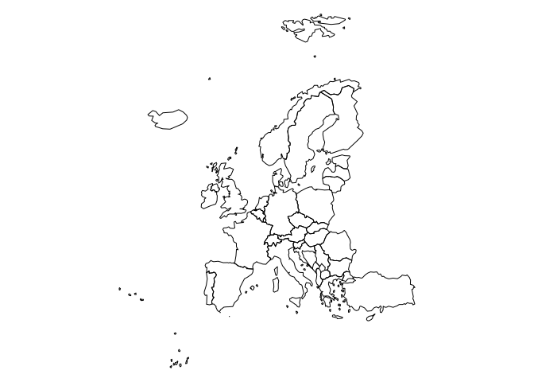

```r
library("sp")
par(mar = c(0,0,0,0))
plot(map)
```

## Create an “sts” object

Using the above ingredients (`ecdc`, `pop`, `map`), we can now create an `"sts"` object via `sts()`.

```r
library("surveillance")

## start of the monthly time series
(start <- as.numeric(strsplit(rownames(ecdc)[1], split="-")[[1]]))
```

```
## [1] 1999    1
```

```r
## IMD0 <- sts(....)  # see help("sts")
```

**solution**

```r
IMD0 <- sts(ecdc, start = start, frequency = 12, # monthly data
            population = pop, map = map)
```

Plot the (aggregated) count time series. Which problem do you notice?

**solution**

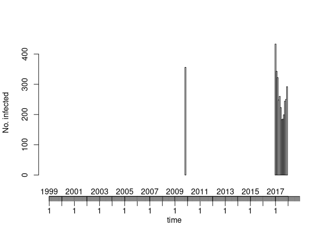

```r
plot(IMD0, type = observed ~ time)
```

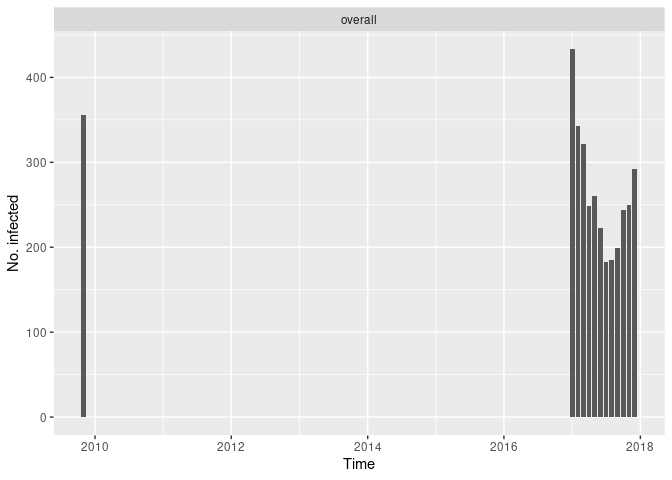

```r
## the time series obviously contains missing values

## ggplot2 version:
autoplot.sts(aggregate(IMD0, by = "unit"))
```

To keep things simple, we restrict the remaining exercises to a subset of the countries:

```r
IMD <- IMD0[, grep("^[ADFNU]", colnames(IMD0))]
```

## Visualizations

### observed ~ time

Plot the overall and country-specific count time series, using either the conventional plot method or `autoplot.sts()` (requires **ggplot2**). The latter has an argument to plot incidences instead of counts.

**solution**

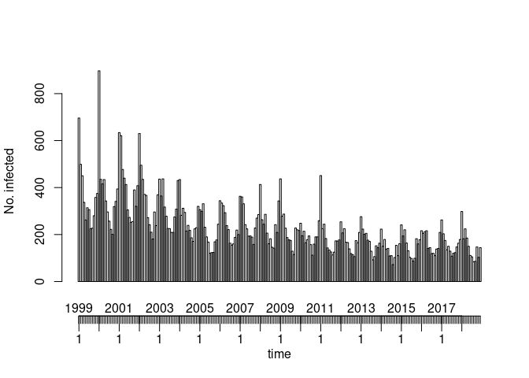

```r
## count time series
plot(IMD, type = observed ~ time)  # overall
```

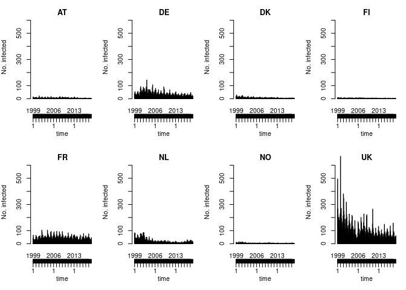

```r
plot(IMD)
```

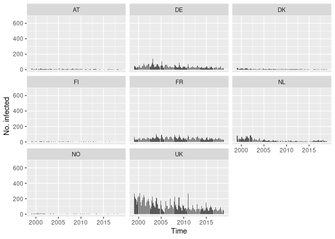

```r
autoplot.sts(IMD)
```

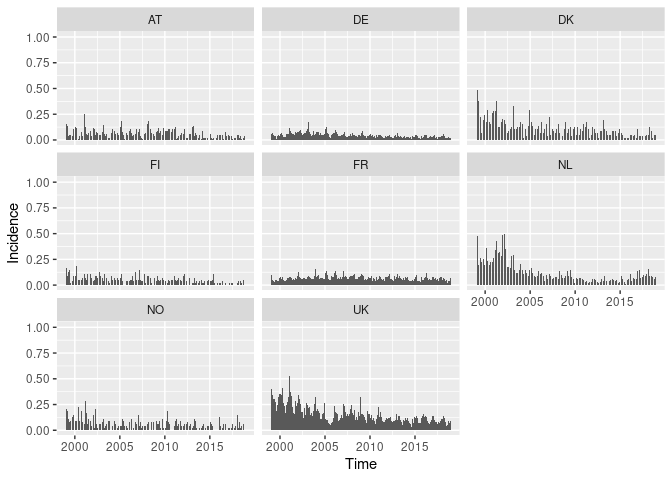

```r
## incidence time series (per 100'000 inhabitants)
autoplot.sts(IMD, population = 100000)
```

### observed ~ unit

Produce a map with the country-specific cumulative number of cases (or incidence) over time. See `help("stsplot_space")` for options.

**solution**

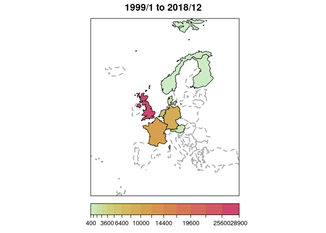

```r
plot(IMD, type = observed ~ unit)
```

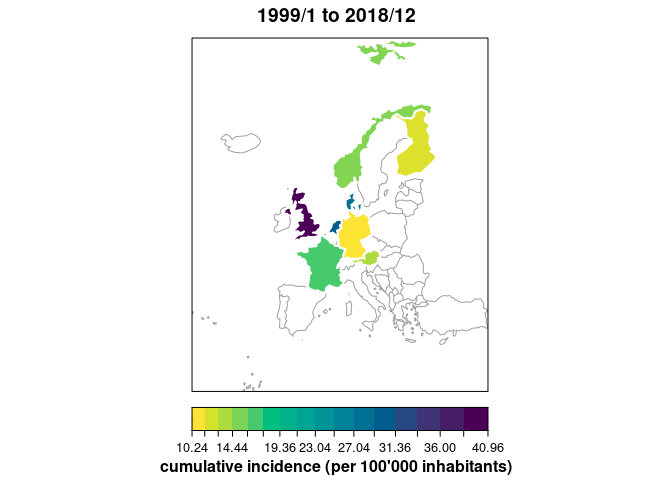

```r
## cumulative incidence (per 100'000 inhabitants),
## using some of the graphical options
plot(IMD, type = observed ~ unit, population = 100000,
     col.regions = hcl.colors(100, rev = TRUE),
     gpar.missing = list(lty = 1, col = 8),
     col = "white", lwd = 2,
     sub = "cumulative incidence (per 100'000 inhabitants)")
```

### Plot via conversion to other data classes

`"sts"` objects can be converted to

- the basic `"ts"` class via `as.ts()`,
- the [**xts**](https://CRAN.R-project.org/package=xts) format via `as.xts.sts()`,
- a “tidy” (long) `data.frame` via `tidy.sts()` that can be used as input for, e.g., [**ggplot2**](https://CRAN.R-project.org/package=ggplot2) or [**lattice**](https://CRAN.R-project.org/package=lattice).

Try to produce some alternative plots of the time series.

**solution**

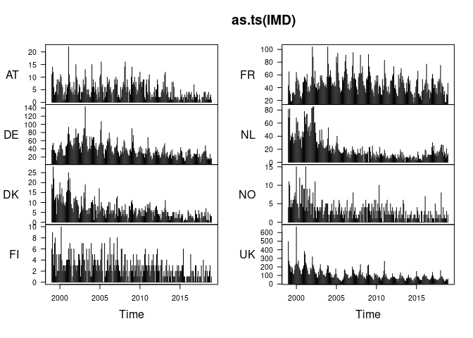

```r
## basic "ts"
plot(as.ts(IMD), las = 1, type = "h")  # note the varying y-axes
```

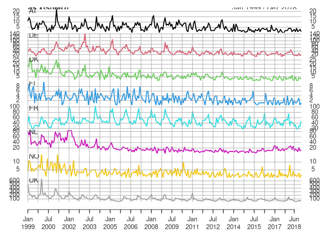

```r
## "xts"
library("xts")
plot(as.xts(IMD), multi.panel = TRUE, yaxis.same = FALSE)
```

```r
## "lattice"
str(IMDDF <- tidy.sts(IMD))
```

```
## 'data.frame':    1920 obs. of  12 variables:
##  $ epoch        : int  1 2 3 4 5 6 7 8 9 10 ...
##  $ unit         : Factor w/ 8 levels "AT","DE","DK",..: 1 1 1 1 1 1 1 1 1 1 ...
##  $ year         : num  1999 1999 1999 1999 1999 ...
##  $ freq         : num  12 12 12 12 12 12 12 12 12 12 ...
##  $ epochInYear  : num  1 2 3 4 5 6 7 8 9 10 ...
##  $ epochInPeriod: num  0.0833 0.1667 0.25 0.3333 0.4167 ...
##  $ date         : Date, format: "1999-01-01" "1999-02-01" "1999-03-01" ...
##  $ observed     : num  11 14 12 6 3 4 4 7 9 3 ...
##  $ state        : logi  FALSE FALSE FALSE FALSE FALSE FALSE ...
##  $ alarm        : logi  NA NA NA NA NA NA ...
##  $ upperbound   : num  NA NA NA NA NA NA NA NA NA NA ...
##  $ population   : int  8822267 8822267 8822267 8822267 8822267 8822267 8822267 8822267 8822267 8822267 ...
```

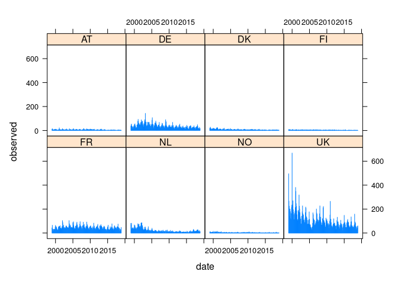

```r
library("lattice")
xyplot(observed ~ date | unit, data = IMDDF, type = "h", as.table = TRUE)
```

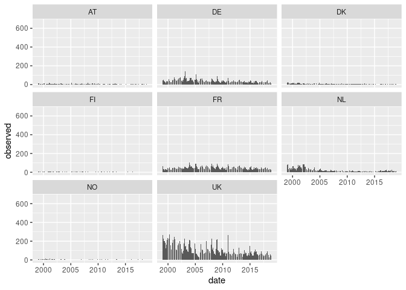

```r
## "ggplot2"
library("ggplot2")
ggplot(IMDDF, aes(x = date, y = observed)) + geom_col() + facet_wrap(~ unit)
```

## Univariate `hhh4()` modelling exercise

### Introduction

We will now estimate simple, univariate `hhh4()` models for the IMD time series from France:

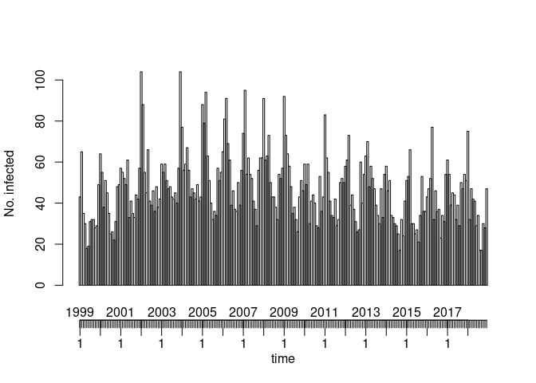

```r
IMD1 <- IMD[,"FR"]
plot(IMD1)
```

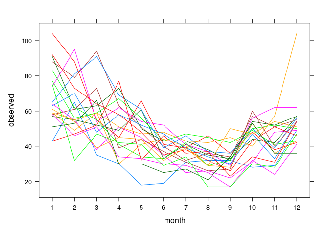

```r
## plot yearly time series to investigate seasonality, here using "lattice"
library("lattice")
xyplot(observed ~ factor(epochInYear), data = tidy.sts(IMD1),
       groups = year, type = "l", xlab = "month")
```

Seasonality can be captured by including transformations of time (sine-cosine terms) as covariates in the model.

In statistical terms, we will fit simple models of the form

$$Y_t | Y_{t-1} \sim \operatorname{NegBin}(\lambda_t y_{t-1} + \nu_t, \phi)$$

where the log-linear predictors $\lambda_t$ (`ar`) and $\nu_t$ (`end`) could both use the regression formula

```r
addSeason2formula(~ t, S = s, period = 12)
```

with `s` being the number of harmonics (each harmonic needing two parameters, amplitude and shift). In mathematical notation, this amounts to log-linear predictors of the form

$$\alpha + \beta t +
\sum_{s=1}^S \left\{ \gamma_s \sin(s \omega t) +
\delta_s \cos(s \omega t) \right\}$$

with fundamental frequency $\omega=2\pi/12$.

### Tasks

1. Estimate a few `hhh4()` models of the above form (with or without trend) and compare them using `AIC()` (Akaike Information Criterion). Note that you can easily estimate a new model with an updated number of harmonics and dropped AR trend from a previous model fit:

```r
fit2 <- update(fit1, ar = list(f = ~ 1), S = list(ar = 2, end = 2))
```

**solution**

```r
## model 1 with time trend and single sinusoidal curve in both components
(form1 <- addSeason2formula(~t, S = 1, period = 12))
```

```
## ~t + sin(2 * pi * t/12) + cos(2 * pi * t/12)
```

```r
fit1 <- hhh4(IMD1, control = list(ar = list(f = form1),
                                  end = list(f = form1),
                                  family = "NegBin1"))
summary(fit1)
```

```
##
## Call:
## hhh4(stsObj = IMD1, control = list(ar = list(f = form1), end = list(f = form1),
##     family = "NegBin1"))
##
## Coefficients:
##                         Estimate    Std. Error
## ar.1                    -0.9109893   0.2132560
## ar.t                    -0.0008338   0.0010388
## ar.sin(2 * pi * t/12)    0.0150849   0.1525758
## ar.cos(2 * pi * t/12)   -0.2375763   0.1751476
## end.1                    3.3798524   0.1314850
## end.t                   -0.0003699   0.0005889
## end.sin(2 * pi * t/12)   0.0558467   0.0890148
## end.cos(2 * pi * t/12)   0.4992783   0.1029933
## overdisp                 0.0304332   0.0047301
##
## Log-likelihood:   -895.61
## AIC:              1809.22
## BIC:              1840.5
##
## Number of units:        1
## Number of time points:  239
```

```r
## for parameter interpretation:
summary(fit1, maxEV = TRUE, amplitudeShift = TRUE, idx2Exp = TRUE)
```

```
##
## Call:
## hhh4(stsObj = IMD1, control = list(ar = list(f = form1), end = list(f = form1),
##     family = "NegBin1"))
##
## Coefficients:
##                       Estimate    Std. Error
## exp(ar.1)              0.4021262   0.0857558
## exp(ar.t)              0.9991665   0.0010379
## ar.A(2 * pi * t/12)    0.2380547   0.1787364
## ar.s(2 * pi * t/12)   -1.5073863   0.0972142
## exp(end.1)            29.3664369   3.8612452
## exp(end.t)             0.9996302   0.0005887
## end.A(2 * pi * t/12)   0.5023919   0.0978861
## end.s(2 * pi * t/12)   1.4594044   0.0612924
## overdisp               0.0304332   0.0047301
##
## Epidemic dominant eigenvalue:  0.26 -- 0.51
##
## Log-likelihood:   -895.61
## AIC:              1809.22
## BIC:              1840.5
##
## Number of units:        1
## Number of time points:  239
```

```r
## model 2 without time trends
form2 <- addSeason2formula(~1, S = 1, period = 12)
fit2 <- hhh4(IMD1, control = list(ar = list(f = form2),
                                  end = list(f = form2),
                                  family = "NegBin1"))
summary(fit2, maxEV = TRUE, amplitudeShift = TRUE, idx2Exp = TRUE)
```

```
##
## Call:
## hhh4(stsObj = IMD1, control = list(ar = list(f = form2), end = list(f = form2),
##     family = "NegBin1"))
##
## Coefficients:
##                       Estimate   Std. Error
## exp(ar.1)              0.399107   0.064866
## ar.A(2 * pi * t/12)    0.219542   0.153981
## ar.s(2 * pi * t/12)   -1.524598   0.091334
## exp(end.1)            26.530592   2.917682
## end.A(2 * pi * t/12)   0.521711   0.101092
## end.s(2 * pi * t/12)   1.475408   0.063261
## overdisp               0.031759   0.004843
##
## Epidemic dominant eigenvalue:  0.32 -- 0.50
##
## Log-likelihood:   -898.38
## AIC:              1810.75
## BIC:              1835.09
##
## Number of units:        1
## Number of time points:  239
```

```r
AIC(fit1, fit2)
```

```
##      df      AIC
## fit1  9 1809.216
## fit2  7 1810.753
```

```r
## model 3 with two harmonics
fit3 <- update(fit2, S = list(ar = 2, end = 2))
AIC(fit2, fit3)
```

```
##      df      AIC
## fit2  7 1810.753
## fit3 11 1802.036
```

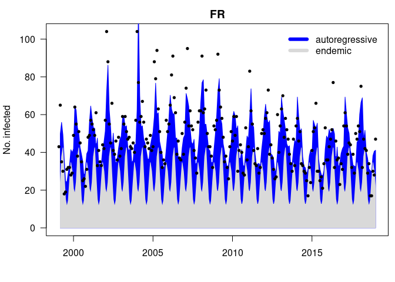

```r
## fitted values and estimated seasonality
plot(fit3)
```

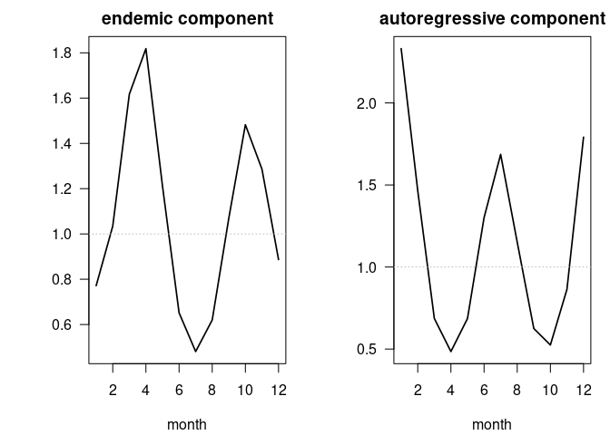

```r
plot(fit3, type = "season")
```

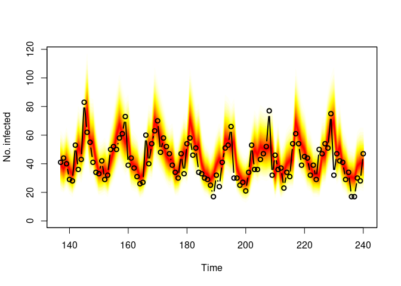

```r
## compute rolling monthly forecasts
osa <- oneStepAhead(fit3, nrow(IMD1) - 2*52, verbose = interactive())
plot(osa)
```

```r
head(quantile(osa))  # for prediction intervals
```

```
##     2.5 % 10.0 % 50.0 % 90.0 % 97.5 %
## 137    24     29     39     52     59
## 138    22     27     37     48     55
## 139    25     30     41     54     61
## 140    21     26     36     47     54
## 141    19     23     33     43     49
## 142    24     29     40     52     59
```

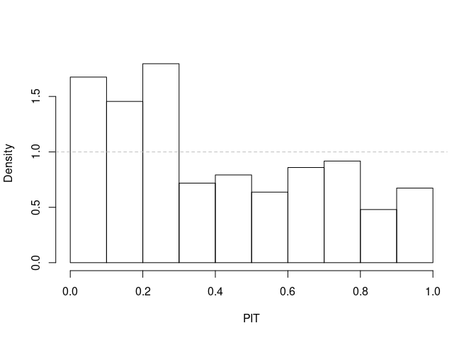

```r
pit(osa)  # model tends to overpredict
```